# beatochess no. 02 (April 2024)

Date: 2024, April 24

File: Zakhodyakin1969.pgn

**Study no. 118** (Table 1 in beatochess-01)

According to tablebase, various alternative first moves also win.

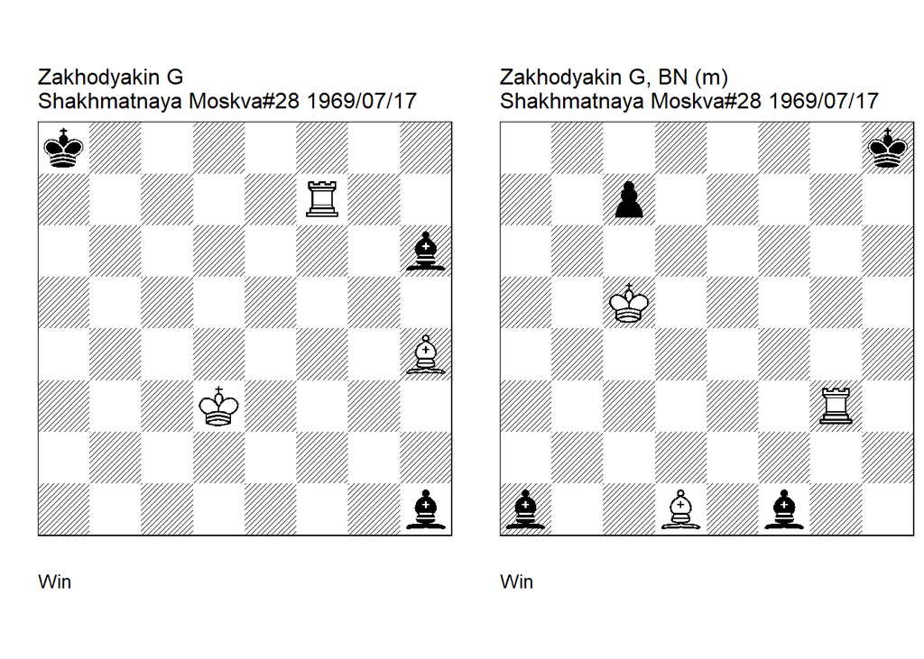

GBR: +0170.00d3a8 FEN: k7/5R2/7b/8/7B/3K4/8/7b w - - 0 1

**Shakhmatnaya Moskva=13** (279) **. U2: Shakhmatnaya Moskva=3** (317) **10-2-1971 U1 U2: Neuenschwander=B beatochess 24/04/2024. 1. Rf6!** (cooks BN1.Kd4, 1.Kc4, 1.Kc3, 1.Bg3, 1.Bf2, are all winning according to tablebase) **1… Bg7 2. Re6!** (2. Rf5 cook BN tablebase ) **2… Bb2 3. Re8+** (3. Bf2! cook ) **3… Ka7 4. Bf2+ Ka6 5. Re6+ Ka5 6. Kc4 Bb7 7. Be1+ Ka4 8. Rb6 1-0**.

GBR: +0170.01c5h8 FEN: 7k/2p5/8/2K5/8/6R1/8/b2B1b2 w - - 0 1

**modification: Neuenschwander=B beatochess 24/04/2024. 1. Rf3 Bg2 2. Rf4 Bb7 3. Rb4 Bg2 4. Rh4+ Kg8 5. Rg4+ 1-0**.

### +0130.01b4b1 (1978). Correction

Date: 2024, April 25

**Study no. 146** (Table 1 in beatochess-01)

In addition to Afek’s cook, there is also the cook **3. Rb4+**. Afek’s cook can be eliminated by an additional black pawn, and uniqueness of the solution can be ensured by changing the main line to **2. Bc8**.

File: Zakhodyakin1978a.pgn

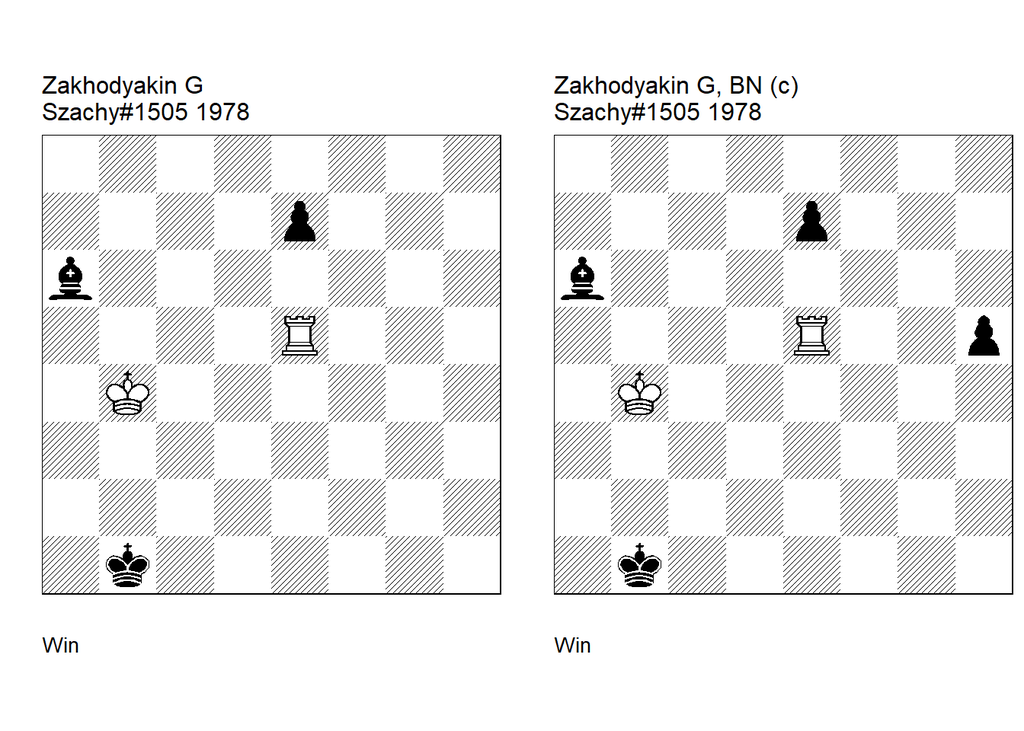

GBR: +0130.01b4b1 FEN: 8/4p3/b7/4R3/1K6/8/8/1k6 w - - 0 1

**Szachy=11** (383) **Szachy/11. U2: Afek=Y HHdbVI 6-8-2020 U2: Neuenschwander=B beatochess 25/04/2024. 1. Kc3! e6! 2. Re4!** (2. Rg5! cook YA 2… Bc8 3. Rg1+ Ka2 4. Rg2+ Kb1 5. Kb3) **2… e5 3. Rxe5** (3. Rb4+! cook BN 3… Kc1 4. Ra4) **3… Bc8 4. Kb3 Kc1 5. Rc5+ 1-0**.

GBR: +0130.01b4b1 FEN: 8/4p3/b7/4R2p/1K6/8/8/1k6 w - - 0 1

**correction: Neuenschwander=B beatochess 25/04/2024. 1. Kc3 e6 2. Re4!** (2. Rg5? h4!) (2. Rxh5? Bc8!) **2… Bc8** (2… h4 3. Rb4+ (3. Rxh4 Bc8) 3… Kc1 4. Ra4) (2… e5 3. Rxe5 or 3.Rb4+ ) **3. Kb3 Kc1 4. Rc4+ 1-0**.

### +0133.00c6a7 (1979). Correction

Date: 2024, April 25

File: Zakhodyakin1979a.pgn

**Study no. 149** (Table 1 in beatochess-01)

In addition to Conrady’s cook, **2.Kxc7** also wins in the intended solution. The version has another mainline and has the original line as a sideline.

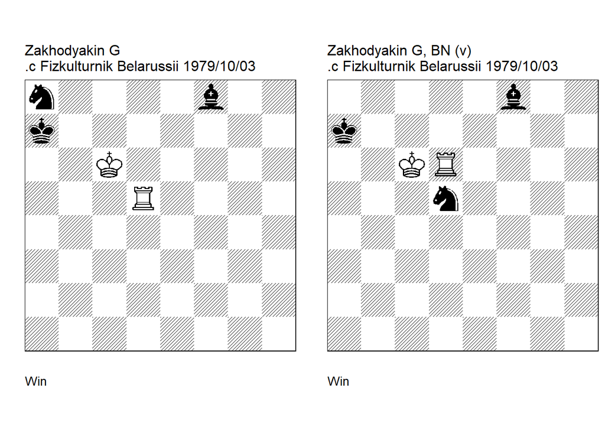

GBR: +0133.00c6a7 FEN: n4b2/k7/2K5/3R4/8/8/8/8 w - - 0 1

**EG 04964. U3: Conrady=H HHdbIII 22486 27-5-2001 U2: Neuenschwander=B beatochess 25/04/2024. 1. Rd7+ Nc7** (1… Ka6 2. Rd8 Nb6! cook HC 3. Rxf8 Ka5 4. Rf5+ Ka6) **2. Rxc7+** (2. Kxc7! cook BN 2… Ka6 3. Rd5!) **2… Kb8 3. Rh7 Ba3 4. Rh1 Be7 5. Rh8+ Ka7 6. Rh7 1-0**.

GBR: +0133.00c6a7 FEN: 5b2/k7/2KR4/3n4/8/8/8/8 w - - 0 1

**version: Neuenschwander=B beatochess 25/04/2024. 1. Rd7+ Kb8** (1… Ka6 2. Rxd5!) (1… Nc7 2. Rxc7+ ( or 2. Kxc7) 2… Kb8 3. Rh7 Ba3 4. Rh1 Be7 5. Rh8+ Ka7 6. Rh7) **2. Rd8+ Ka7 3. Rxf8!** (3. Rxd5? Bh6!) **3… Nb4+ 4. Kb5 1-0**.

### +3230.00c6b8 (1981). Correction

Date: 2024, April 30

File: Zakhodyakin1981b.pgn

**Study no. 188** (Table 1 in beatochess-01)

Zakhodyakin worked on the R-b material constellation quite a bit. The additional black pawn on h4 removes the cooks.

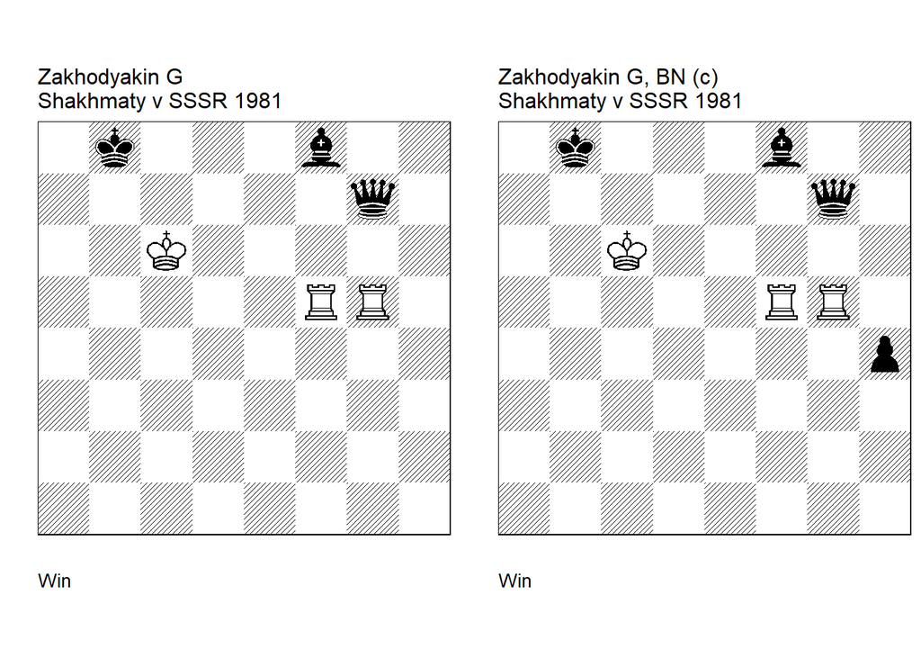

GBR: +3230.00c6b8 FEN: 1k3b2/6q1/2K5/5RR1/8/8/8/8 w - - 0 1

**Shakhmaty v SSSR/1. U2: Afek=Y HHdbVI 6-8-2020. 1. Rb5+ Ka8** (1… Kc8 2. Rxg7 Bxg7 3. Rg5) **2. Ra5+ Qa7** (2… Kb8 3. Rgb5+) **3. Rxa7+** (3. Rh5! cook YA ) (3. Rgd5! cook YA ) **3… Kxa7 4. Rg4!** (4. Rg6! cook YA ) **4… Bh6 5. Kc7 Ka6 6. Rg6+ 1-0**.

GBR: +3230.01c6b8 FEN: 1k3b2/6q1/2K5/5RR1/7p/8/8/8 w - - 0 1

**correction: Neuenschwander=B beatochess 30/04/2024. 1. Rb5+ Ka8 2. Ra5+ Qa7** ( 2… Kb8 3. Rgb5+) **3. Rxa7+** (3. Rgd5? Qxa5) **3… Kxa7 4. Rg4! Bh6** (4… h3 5. Rh4 h2 6. Rxh2 Bb4 (6… Bg7 7. Rh7) 7. Ra2+ Kb8 8. Rb2) **5. Kc7 Ka6 6. Rg6+ 1-0**.